# Dicentrics characteristic limits

## Compare proband vs. control

The first step is to input the number of dicentrics and the number of cells counted for the proband (case) and for the control. A significant P-value suggests that the proband was exposed two a dose ($D>0Gy$) and the calculation of the dose shall be performed if an appropriate calibration curve is available.

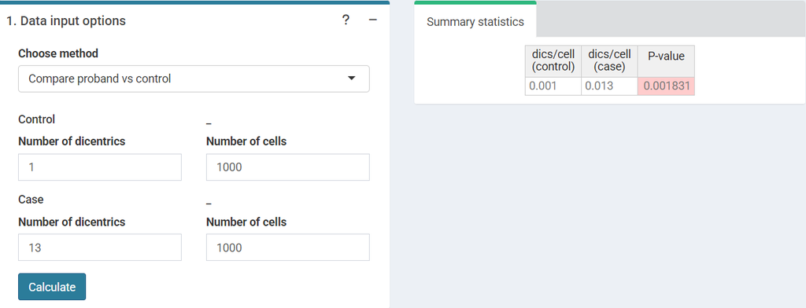

‘Data input options’ in the characteristic limits module - Compare proband vs control method.

This step is accomplished in R by `poisson.test()` function:

```r
control_data <- c(aberr = 1, cells = 1000)

proband_data <- c(aberr = 13, cells = 1000)


result_data <- matrix(c(control_data["aberr"]/control_data["cells"],
    proband_data["aberr"]/proband_data["cells"], stats::poisson.test(c(proband_data["aberr"],
        control_data["aberr"]), c(proband_data["cells"], control_data["cells"]))$p.value),
    ncol = 3, nrow = 1)

colnames(result_data) <- c("dics/cell (control)", "dics/cell (case)",
    "P-value")
```

```r
result_data
```

```
#>      dics/cell (control) dics/cell (case)     P-value
#> [1,]               0.001            0.013 0.001831055
```

## Characteristic limits

The user can choose the type I error rate($α$)(false positive rate) and the type II error rate ($β$) (false negative rate).

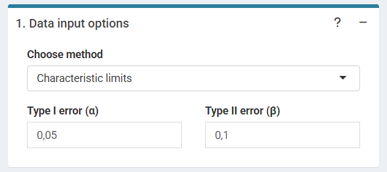

‘Data input options’ in the characteristic limits module - Characteristic limits.

The input data are: the number of dicentrics and cells of the control data if ($Number of dics and cells$) is selected or the mean number of dicentrics per cell if ($Dics per cell$) is selected. Input the pre-calculated curve in `.rds` format obtained in the dose-effect fitting module.

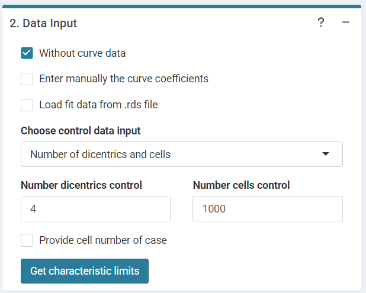

‘Data input options’ in the characteristic limits module - Characteristic limits - Without curve data option.

or input the curve coefficients manually in case the user wants to use a pre-existing curve calculated outside of Biodose Tools.

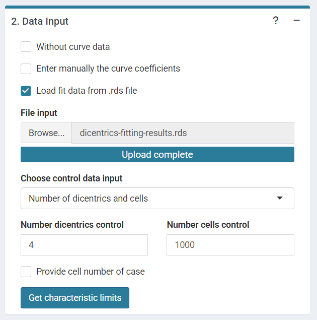

‘Data input options’ in the characteristic limits module - Characteristic limits - Loaded data .rds option.

If these information is not available, choose ($Without curve data$) and the dose will not be calculated.

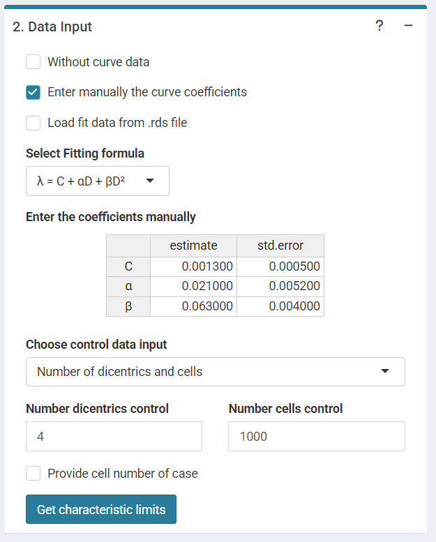

‘Data input options’ in the characteristic limits module - Characteristic limits - Manually entered curve data option.

This step is accomplished in R by calling the `calculate_characteristic_limits()` function that gives the decision threshold and the detection limit:

```r
cells_proband <- c(20, 50, 100, 200, 500, 1000)
control_data <- c(aberr = 4,
                  cells = 1000)

c_limits <- sapply(cells_proband, function(x) calculate_characteristic_limits(
  y0 = control_data["aberr"],
  n0 = control_data["cells"],
  n1 = x,
  alpha = 0.05,
  beta = 0.1,
  ymax = 100,
  type = "var"
  ))
```

```r
c_limits
```

```
#>                    [,1]    [,2]    [,3]    [,4]     [,5]     [,6]
#> decision_threshold 1       1       2       3        7        12
#> detection_limit    3.88972 3.88972 5.32232 6.680783 11.77091 17.78159
```

For the Minimum resolvable dose ($(Gy)$) and the Dose at detection limit ($(Gy)$) `project_yield()` function is applied:

```r
fit_results_list <- system.file("extdata", "dicentrics-fitting-results.rds", package = "biodosetools")%>%
  readRDS()
fit_coeffs <- fit_results_list$fit_coeffs[, "estimate"]

 est_dec <- sapply((unlist(c_limits["decision_threshold", ]) + 1) / cells_proband, function(x) project_yield(
   yield = x,
   type = "estimate",
   general_fit_coeffs = fit_coeffs,
   general_fit_var_cov_mat = NULL,
   protracted_g_value = 1,
   conf_int = 0))

 est_det <- sapply(unlist(c_limits["detection_limit", ]) / cells_proband, function(x) project_yield(
   yield = x,
   type = "estimate",
   general_fit_coeffs = fit_coeffs,
   general_fit_var_cov_mat = NULL,
   protracted_g_value = 1,
   conf_int = 0))
```

```r
est_dec
```

```
#> [1] 1.0956559 0.6344613 0.5284423 0.4030546 0.3443595 0.2954731
```

```r
est_det
```

```
#> [1] 1.5918121 0.9474389 0.7560874 0.5662469 0.4503848 0.3712934
```

Results are displayed in the UI as a table and can be saved in .csv and .tex

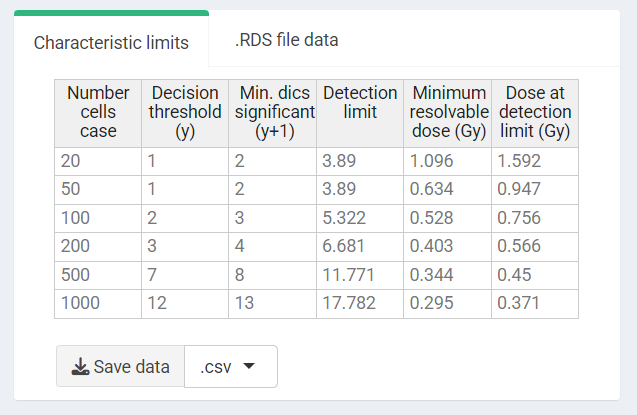

‘Results’ tabbed box in the characteristic limits module - Characteristic limits.